# Share of Public and Private Sector in Health Center

**This project deals with the exploratory analysis of the NFHS-3 and NFHS-4 data set by setting out research questions, and then exploring relationship between variables to answer those questions.**

Access to health care, and utilization of health care, is increasingly being identified as one of the most pressing challenges to the health care system, and by extending health policy, in many developing as well as some developed nations. This analysis is taking place against the background of increasing recognition of health as a human right, an important component of development and one of the main dimension and factors in overall wellbeing.

## Part 1: Data Set

#### Load packages

```r
library(ggplot2)
library(dplyr)
```

#### Load data

```r
myData2 <- read.csv(file='C:\\Users\\Shivang Keshari\\Downloads\\multi\\myFile2.csv', header=TRUE)

myData2_tot <- myData2 %>% filter(Dist=="Total")

myData2_tot <- myData2_tot %>%
          mutate(sum_c = (A+B+C+D+E))

myData2_tot <- myData2_tot %>% filter(States!="All India/ Total")

myData1 <- read.csv(file='C:\\Users\\Shivang Keshari\\Downloads\\multi\\myFile1.csv', header=TRUE)

myData1_st <- myData1 %>% filter(S_No!="India")

ind_rec <- myData1 %>% filter(Ind_St == "India")

max_pub <- myData1_st %>% filter(Pub_total == max(myData1_st$Pub_total))

min_pub <- myData1_st %>% filter(Pub_total == min(myData1_st$Pub_total))

max_pri <- myData1_st %>% filter(Pri_total == max(myData1_st$Pri_total))

min_pri <- myData1_st %>% filter(Pri_total == min(myData1_st$Pri_total))

myData3 <- read.csv(file='C:\\Users\\Shivang Keshari\\Downloads\\multi\\myFile3.csv', header=TRUE)

st_cou <- count(myData3, State)

max_st <- st_cou %>% filter(n == max(st_cou$n))

min_st <- st_cou %>% filter(n == min(st_cou$n))
```

## Part 2: Research Questions

**Research quesion 4:**

How does the health care utilization has made the public and private health care systems differential in the indian states ?

## Part 3: Data Analysis

**Interrogation 4:**

How does the health care utilization has made the public and private health care systems differential in the indian states ?

**SIGNIFICANCE**

About five percent of the Indian government’s annual expenditure goes towards healthcare. According to the World Health Organization (WHO), most of the healthcare expenditure in India - which averages $75 per capita - comes from the private spending of households. The standards of India’s public healthcare system contrast starkly with its private counterpart, which generates billions of dollars annually from medical tourism.

For local Indians, the cost of private healthcare is about four times greater than the country’s public healthcare.

**EXPLANATION**

The line graph below shows the total number of health care centers in different states of India.As per the graph,Uttar Pradesh is having the highest number of health care centers.

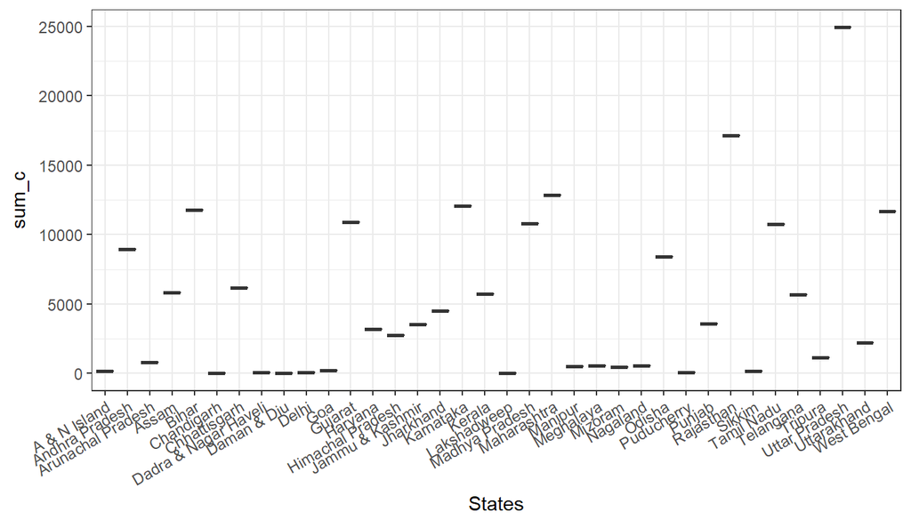

```r
ggplot(myData2_tot, aes(x = States, y = sum_c)) +
     geom_boxplot()+
     theme_bw() +
     theme(axis.text.x = element_text(angle = 30, hjust = 1))
```

```r
ind_pub_tot <- ind_rec$Pub_total

ind_pub_tot
```

```
## [1] 34.4
```

**EXPLANATION**

This line graph shows the total number of public health care centers in our country. Which is just **34%** of the total availability, with Sikkim having the higgest number of public health care centers and the percentage being **91.8%** ,while Bihar having the lowest with just **6.7%**.

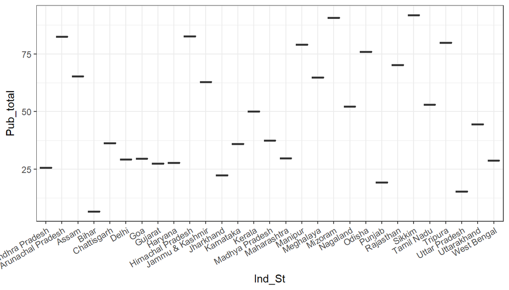

```r
ggplot(myData1_st, aes(x = Ind_St, y = Pub_total)) +
      geom_boxplot()+
   theme_bw() +
   theme(axis.text.x = element_text(angle = 30, hjust = 1))
```

```r
cat(sprintf("\"%s\" \"%f\"\n", max_pub$Ind_St[1], max_pub$Pub_total[1]))
```

```
## "Sikkim" "91.800000"
```

```r
cat(sprintf("\"%s\" \"%f\"\n", min_pub$Ind_St[1], min_pub$Pub_total[1]))
```

```
## "Bihar" "6.700000"
```

```r
ind_pri_tot <- ind_rec$Pri_total

ind_pri_tot
```

```
## [1] 64.8
```

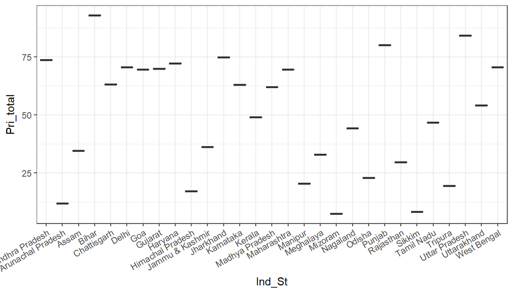

```r
ggplot(myData1_st, aes(x = Ind_St, y = Pri_total)) +
      geom_boxplot()+
   theme_bw() +
   theme(axis.text.x = element_text(angle = 30, hjust = 1))
```

```r
cat(sprintf("\"%s\" \"%f\"\n", max_pri$Ind_St[1], max_pri$Pri_total[1]))
```

```
## "Bihar" "92.900000"
```

```r
cat(sprintf("\"%s\" \"%f\"\n", min_pri$Ind_St[1], min_pri$Pri_total[1]))
```

```
## "Mizoram" "7.400000"
```